# Scaling AI for GEOINT: Video Search & Summarization

### GEOINT 2026 Symposium · May 5, 2026 · Aurora, CO

**Kevin Green, Ph.D. & Keith Ober · NVIDIA WWFO**

> *"You have 500 hours of overhead video from last week's operation.* *The commander needs a situation report — in the next 10 minutes. How?"*

A human analyst watching video in real time is bounded by the clock. This notebook demonstrates the **NVIDIA Video Search and Summarization (VSS) Blueprint** — an AI pipeline that automatically captions, indexes, and answers questions over hours of footage in minutes, using live NVIDIA NIM inference.

**Three Videos. Three Missions. One Key Lesson.**

| Mission | Video | Goal |
| --- | --- | --- |
| **1 — Captioning** | Warehouse Safety | VLM describes every scene — zero labels, zero training |
| **2 — Summarization** | Warehouse Operations | Raw captions compressed into an operational report |
| **3 — Interactive Q&A** | Access Control (Tailgating) | Ask questions in plain English, get grounded answers |

Along the way, we discover a critical insight: **static frames capture snapshots, but video captures the story.** This distinction matters for mission-critical event detection.

| NIM Model | Role | Production VSS Equivalent |
| --- | --- | --- |
| `nemotron-nano-12b-v2-vl` | VLM frame captioning + video inference | Cosmos Reason2 8B |
| `nvidia-nemotron-nano-9b-v2` | LLM summarization + Q&A | Nemotron Nano 9B |
| `nv-embedqa-e5-v5` | Dense embeddings (1024 dim) | Cosmos Embed 1 |

### How This Session Maps to the Training Abstract

This training is delivered in two parts that together cover the full scope of the published training abstract:

**Part 1 — Slides (presented by Keith Ober & Kevin Green):** Foundational concepts covering AI scaling fundamentals, GPU computing basics, the Five Layer AI Cake architecture, model serving with Triton Inference Server, AI Factory for Government reference designs, resource management, and security/governance for regulated environments.

**Part 2 — Hands-On Lab (this notebook, presented by Kevin Green):** An interactive Jupyter notebook demonstrating the NVIDIA VSS Blueprint in action. The lab applies the concepts from Part 1 to a concrete GEOINT workflow: video captioning with Vision Language Models, recursive summarization with LLMs, dense embeddings for semantic search, and interactive Q&A over video archives.

| Training Abstract Section | Where Covered |
| --- | --- |
| 1. AI Scaling Fundamentals | Slides: Major Trends, AI Challenges |
| 2. GPU Computing Basics | Slides: Five Layer AI Cake, Workload Projection |
| 3. Building Efficient Data Pipelines | Slides + Lab: Pipeline diagram, video chunking, frame extraction |
| 4. Model Serving and Deployment | Slides: Triton · Lab: NVIDIA NIM microservices |
| 5. AI Blueprints and Accelerators | Lab: All three missions using the VSS Blueprint |
| 6. Practical Resource Management | Slides: AI Factory, deployment topologies |
| 7. Data Organization with Embeddings | Lab: Mission 3 — FAISS vector index, semantic search, RAG |
| 8. Security and Trustworthy AI | Slides + Lab: Government-ready NIMs, governance section |

## Part 0: Setup

Install dependencies, configure NIM API access, and define all helper functions. The notebook calls NVIDIA's hosted NIM endpoints at `integrate.api.nvidia.com` — no local GPU required.

```python
# ── Install dependencies (run once) ─────────────────────────────────
import subprocess, sys
for pkg in ["openai", "numpy", "matplotlib", "Pillow", "faiss-cpu"]:
    subprocess.check_call([sys.executable, "-m", "pip", "install", "-q", "--break-system-packages", pkg],
                          stdout=subprocess.DEVNULL, stderr=subprocess.DEVNULL)
print("All packages ready.")
```

```
All packages ready.
```

```python
# ── Imports ─────────────────────────────────────────────────────────
import os, sys, json, time, base64, warnings, hashlib
from pathlib import Path
from textwrap import fill
from concurrent.futures import ThreadPoolExecutor, as_completed

import numpy as np
import matplotlib.pyplot as plt
import matplotlib.gridspec as gridspec
from matplotlib.patches import FancyBboxPatch
from PIL import Image as PILImage
from IPython.display import display, HTML, Markdown, Video
import faiss

warnings.filterwarnings('ignore')

# ── Projector-optimized display ─────────────────────────────────────
display(HTML("""<style>
.jp-OutputArea-output { font-size: 15px !important; }
.jp-RenderedHTMLCommon { font-size: 15px !important; }
</style>"""))

# ── Dark stage-ready theme ──────────────────────────────────────────
plt.rcParams.update({
    'figure.facecolor': '#0d1117', 'axes.facecolor': '#161b22',
    'axes.edgecolor': '#30363d', 'text.color': '#e6edf3',
    'axes.labelcolor': '#e6edf3', 'xtick.color': '#8b949e',
    'ytick.color': '#8b949e', 'grid.color': '#21262d',
    'grid.linewidth': 0.6, 'font.size': 13,
    'axes.titlesize': 14, 'figure.titlesize': 16,
    'legend.facecolor': '#161b22', 'legend.edgecolor': '#30363d',
})
ACCENT, WARM, SUCCESS, MUTED = '#58a6ff', '#f78166', '#3fb950', '#8b949e'
NIM_GREEN = '#76b900'

print("Display and theme configured for projector.")
```

```
Display and theme configured for projector.
```

### NIM API Configuration

Set your NIM API key below. Get one free at build.nvidia.com. Pre-computed results are included — you can run the full notebook without a key. Cells that need a live key will show a clear message.

```python
# ── NIM API Key ─────────────────────────────────────────────────────
# Option 1: Set directly
# NIM_API_KEY = "nvapi-YOUR-KEY-HERE"

# Option 2: Load from environment or ~/.secrets
NIM_API_KEY = os.environ.get('NIM_API_KEY', '')
if not NIM_API_KEY:
    secrets = Path.home() / '.secrets'
    if secrets.exists():
        for line in secrets.read_text().splitlines():
            line = line.strip()
            if line.startswith('export NIM_API_KEY'):
                NIM_API_KEY = line.split('=', 1)[1].strip().strip("'").strip('"')

# ── NIM Endpoints ───────────────────────────────────────────────────
NIM_BASE_URL = "https://integrate.api.nvidia.com/v1"
VLM_MODEL    = "nvidia/nemotron-nano-12b-v2-vl"
LLM_MODEL    = "nvidia/nvidia-nemotron-nano-9b-v2"
EMBED_MODEL  = "nvidia/nv-embedqa-e5-v5"

# ── Data Paths ──────────────────────────────────────────────────────
DATA_DIR       = Path("data")
VIDEOS_DIR     = DATA_DIR / "videos"
CAPTIONS_DIR   = DATA_DIR / "captions"
EMBEDDINGS_DIR = DATA_DIR / "embeddings"
FRAMES_DIR     = DATA_DIR / "frames"
for d in [VIDEOS_DIR, CAPTIONS_DIR, EMBEDDINGS_DIR, FRAMES_DIR]:
    d.mkdir(parents=True, exist_ok=True)

print(f"{'✓' if NIM_API_KEY else '✗'} NIM_API_KEY: {'set (' + NIM_API_KEY[:8] + '...)' if NIM_API_KEY else 'NOT SET — pre-computed data will be used'}")
print(f"  Endpoint : {NIM_BASE_URL}")
print(f"  VLM      : {VLM_MODEL}")
print(f"  LLM      : {LLM_MODEL}")
print(f"  Embed    : {EMBED_MODEL}")
```

```
✓ NIM_API_KEY: set (nvapi-rL...)
  Endpoint : https://integrate.api.nvidia.com/v1
  VLM      : nvidia/nemotron-nano-12b-v2-vl
  LLM      : nvidia/nvidia-nemotron-nano-9b-v2
  Embed    : nvidia/nv-embedqa-e5-v5
```

### Optional: Clear Cached Data

Run the cell below **only** if you want to regenerate all results from scratch. Skip this cell during the live demo, since the cached data ensures instant results even if the NIM API is slow or unavailable.

**To clear cached data:** Uncomment the `CLEAR_CACHE = True` line in the cell below, then run the cell. All cached captions, summaries, embeddings, and extracted frames will be deleted. You will need to re-run the entire notebook to regenerate them.

```python
# ⚠ OPTIONAL — Skip this cell during the live demo
# Uncomment the line below and run to clear all cached data

# CLEAR_CACHE = True

if 'CLEAR_CACHE' in dir() and CLEAR_CACHE:
    for folder in [CAPTIONS_DIR, EMBEDDINGS_DIR]:
        for f in folder.glob("*"):
            if f.is_file():
                f.unlink()
                print(f"  Deleted: {f.name}")
    for d in FRAMES_DIR.iterdir():
        if d.is_dir():
            for f in d.glob("*"):
                f.unlink()
            d.rmdir()
            print(f"  Deleted: {d.name}/")
    print("\n✓ All cached data cleared. Re-run notebook to regenerate.")
else:
    print("Cache intact. To clear, uncomment CLEAR_CACHE = True above and re-run.")
```

[output not shown]

### Helper Functions

```python
# ── NIM API Helpers ─────────────────────────────────────────────────
from openai import OpenAI
import subprocess

def get_nim_client():
    return OpenAI(base_url=NIM_BASE_URL, api_key=NIM_API_KEY)

def caption_frame_nim(image_path, prompt=None):
    if not NIM_API_KEY:
        raise RuntimeError("NIM_API_KEY required for live captioning")
    with open(image_path, "rb") as f:
        b64 = base64.b64encode(f.read()).decode()
    if prompt is None:
        prompt = ("Describe this surveillance frame in detail. "
                  "What objects, people, activities, and safety concerns do you observe?")
    client = get_nim_client()
    resp = client.chat.completions.create(
        model=VLM_MODEL,
        messages=[{"role": "user", "content": [
            {"type": "image_url", "image_url": {"url": f"data:…"}},
            {"type": "text", "text": prompt}
        ]}],
        max_tokens=512, temperature=0.3, top_p=0.4,
    )
    return resp.choices[0].message.content

def video_native_caption(video_path, prompt):
    """Send an entire video to the VLM for motion-aware inference."""
    if not NIM_API_KEY:
        raise RuntimeError("NIM_API_KEY required for video inference")
    with open(video_path, "rb") as f:
        b64 = base64.b64encode(f.read()).decode()
    client = get_nim_client()
    resp = client.chat.completions.create(
        model=VLM_MODEL,
        messages=[{"role": "user", "content": [
            {"type": "video_url", "video_url": {"url": f"data:video/mp4;base64,{b64}"}},
            {"type": "text", "text": prompt}
        ]}],
        max_tokens=1024, temperature=0.3,
    )
    return resp.choices[0].message.content

def llm_complete(prompt, system="You are a concise video analytics assistant."):
    if not NIM_API_KEY:
        raise RuntimeError("NIM_API_KEY required for live LLM calls")
    client = get_nim_client()
    resp = client.chat.completions.create(
        model=LLM_MODEL,
        messages=[{"role": "system", "content": system},
                  {"role": "user", "content": prompt}],
        max_tokens=2048, temperature=0.3,
    )
    return resp.choices[0].message.content

def embed_texts(texts, input_type="passage"):
    if not NIM_API_KEY:
        raise RuntimeError("NIM_API_KEY required for live embedding")
    client = get_nim_client()
    resp = client.embeddings.create(
        model=EMBED_MODEL, input=texts,
        extra_body={"input_type": input_type, "truncate": "END"},
    )
    return [e.embedding for e in resp.data]

def embed_query(query):
    return embed_texts([query], input_type="query")[0]

# ── Video Processing Helpers ────────────────────────────────────────
def get_video_duration(path):
    cmd = ["ffprobe", "-v", "quiet", "-print_format", "json", "-show_format", str(path)]
    out = subprocess.check_output(cmd)
    return float(json.loads(out)["format"]["duration"])

def extract_frames_from_video(video_path, output_dir, chunk_duration=10.0, frames_per_chunk=3):
    output_dir = Path(output_dir)
    output_dir.mkdir(parents=True, exist_ok=True)
    duration = get_video_duration(video_path)
    chunks = []
    chunk_id = 0
    t = 0.0
    while t < duration:
        end = min(t + chunk_duration, duration)
        frame_paths = []
        for fi in range(frames_per_chunk):
            frac = (fi + 0.5) / frames_per_chunk
            ts = t + frac * (end - t)
            out_path = output_dir / f"chunk_{chunk_id:02d}_frame_{fi:02d}.jpg"
            if not out_path.exists():
                subprocess.run(["ffmpeg", "-v", "quiet", "-ss", str(ts), "-i", str(video_path),
                                "-vframes", "1", "-q:v", "2", str(out_path)], check=False)
            if out_path.exists():
                frame_paths.append(str(out_path))
        chunks.append({"chunk_id": chunk_id, "start_time": t, "end_time": end, "frame_paths": frame_paths})
        t = end
        chunk_id += 1
    return chunks

def get_cover_frame(chunks_data, frames_dir):
    cover = {}
    for c in chunks_data:
        fps = c.get("frame_paths", [])
        if fps:
            cover[c["chunk_id"]] = PILImage.open(fps[len(fps)//2])
    return cover

def recursive_summarize(captions, group_size=3):
    texts = [f"[{c['start_time']:.0f}s-{c['end_time']:.0f}s] {c['caption']}" for c in captions]
    groups = [texts[i:i+group_size] for i in range(0, len(texts), group_size)]
    group_summaries = []
    for i, grp in enumerate(groups):
        prompt = ("Summarize these sequential video observations into a single "
                  "coherent paragraph. Preserve key details and timestamps.\n\n"
                  + "\n".join(grp))
        summary = llm_complete(prompt)
        group_summaries.append(summary)
        print(f"  Group {i+1}/{len(groups)} summarized")
    final_prompt = ("You are a video analytics report generator. Synthesize these "
                    "group summaries into a structured operational report with:\n"
                    "- Executive Summary\n- Key Events (with timestamps)\n"
                    "- Safety Observations\n- Recommendations\n\n"
                    + "\n\n".join(group_summaries))
    final_report = llm_complete(final_prompt)
    return {"stages": 2, "group_summaries": group_summaries, "final_report": final_report}

print("All helper functions defined. ✓")
```

```
All helper functions defined. ✓
```

## Part 1: Meet the Videos

Before the AI sees anything, **you** watch first. Form your own mental model of what happened in each clip, then compare it against what the AI produces. That contrast — *"I just watched that, and the AI described exactly what I saw"* — is the point.

```python
# ── Video Catalog ───────────────────────────────────────────────────
VIDEOS = {
    "warehouse_safety": {
        "file": "warehouse_safety_0002.mp4",
        "title": "Warehouse Safety Monitoring",
        "duration": "~30s", "size": "7.4 MB",
        "mission": "Mission 1: Video Captioning",
        "scenario": "PPE compliance, worker safety, equipment operations",
        "mission_color": "#3fb950",
        "source": "NVIDIA VSS Public Safety Blueprint (NGC)",
    },
    "warehouse_ops": {
        "file": "warehouse_short.mp4",
        "title": "Warehouse Operations",
        "duration": "10s", "size": "0.9 MB",
        "mission": "Mission 2: Video Summarization",
        "scenario": "Operational activity monitoring, logistics flow",
        "mission_color": "#58a6ff",
        "source": "NVIDIA VSS Dev Profile Sample Data (NGC)",
    },
    "tailgating": {
        "file": "test1.mp4",
        "title": "Access Control — Tailgating",
        "duration": "31s", "size": "5.0 MB",
        "mission": "Mission 3: Interactive Q&A",
        "scenario": "Unauthorized entry detection, access point monitoring",
        "mission_color": "#f78166",
        "source": "NVIDIA VSS Public Safety Tailgate Blueprint (NGC)",
    },
}

html = ['<div style="display:flex;flex-direction:column;gap:16px;max-width:900px;">']
for key, v in VIDEOS.items():
    path = VIDEOS_DIR / v["file"]
    exists = path.exists()
    status = f'<span style="color:#3fb950">✓ ready</span>' if exists else '<span style="color:#f78166">✗ not found</span>'
    html.append(f'''
    <div style="border:2px solid {v['mission_color']};border-radius:8px;overflow:hidden;background:#0d1117;">
      <div style="display:flex;gap:16px;padding:12px;">
        <div style="flex:0 0 320px;">
          {'<video width="320" height="180" controls style="display:block;background:#000;border-radius:4px;"><source src="' + str(path) + '" type="video/mp4"></video>' if exists else '<div style="width:320px;height:180px;background:#161b22;border-radius:4px;display:flex;align-items:center;justify-content:center;color:#8b949e;">Video not found</div>'}
        </div>
        <div style="flex:1;color:#e6edf3;">
          <div style="font-size:1.1em;font-weight:bold;color:{v['mission_color']}">{v['mission']}</div>
          <div style="font-size:1.0em;font-weight:bold;margin-top:4px;">{v['title']}</div>
          <div style="color:#8b949e;font-size:0.85em;margin-top:4px;">{v['duration']} · {v['size']} · {status}</div>
          <div style="color:#58a6ff;font-size:0.88em;margin-top:6px;">{v['scenario']}</div>
          <div style="color:#8b949e;font-size:0.78em;margin-top:4px;font-family:monospace;">Source: {v['source']}</div>
        </div>
      </div>
    </div>''')
html.append('</div>')
display(HTML(''.join(html)))
missing = [v["file"] for v in VIDEOS.values() if not (VIDEOS_DIR / v["file"]).exists()]
if missing:
    print(f"\n⚠ Missing videos: {missing}")
    print(f"  Copy them to: {VIDEOS_DIR.resolve()}")
else:
    print(f"\n✓ All {len(VIDEOS)} videos ready in {VIDEOS_DIR}")
```

[video not shown]

Mission 1: Video Captioning

Warehouse Safety Monitoring

~30s · 7.4 MB · ✓ ready

PPE compliance, worker safety, equipment operations

Source: NVIDIA VSS Public Safety Blueprint (NGC)

[video not shown]

Mission 2: Video Summarization

Warehouse Operations

10s · 0.9 MB · ✓ ready

Operational activity monitoring, logistics flow

Source: NVIDIA VSS Dev Profile Sample Data (NGC)

[video not shown]

Mission 3: Interactive Q&A

Access Control — Tailgating

31s · 5.0 MB · ✓ ready

Unauthorized entry detection, access point monitoring

Source: NVIDIA VSS Public Safety Tailgate Blueprint (NGC)

```
✓ All 3 videos ready in data/videos
```

### How VSS Works: The Pipeline

Every mission follows the same pipeline. The only difference is where we stop and what we ask.

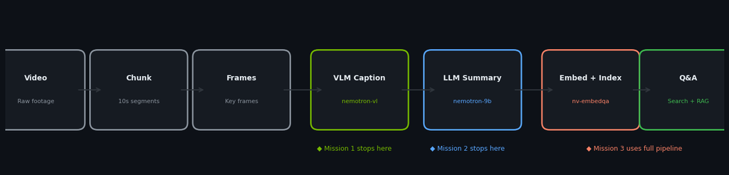

```python
fig, ax = plt.subplots(figsize=(14, 3.5))
fig.patch.set_facecolor('#0d1117')
ax.set_facecolor('#0d1117')
ax.axis('off')
ax.set_xlim(0, 14); ax.set_ylim(0, 3.5)
stages = [
    ("Video", 0.5, "#8b949e", "Raw footage"),
    ("Chunk", 2.5, "#8b949e", "10s segments"),
    ("Frames", 4.5, "#8b949e", "Key frames"),
    ("VLM Caption", 6.8, NIM_GREEN, "nemotron-vl"),
    ("LLM Summary", 9.0, "#58a6ff", "nemotron-9b"),
    ("Embed + Index", 11.3, "#f78166", "nv-embedqa"),
    ("Q&A", 13.2, "#3fb950", "Search + RAG"),
]
for name, x, color, sub in stages:
    box = FancyBboxPatch((x-0.7, 1.0), 1.6, 1.4, boxstyle="round,pad=0.15",
                          facecolor='#161b22', edgecolor=color, linewidth=2)
    ax.add_patch(box)
    ax.text(x+0.1, 1.95, name, ha='center', va='center', fontsize=10, fontweight='bold', color='#e6edf3')
    ax.text(x+0.1, 1.45, sub, ha='center', va='center', fontsize=8, color=color)
for i in range(len(stages)-1):
    x1 = stages[i][1] + 0.9
    x2 = stages[i+1][1] - 0.6
    ax.annotate('', xy=(x2, 1.7), xytext=(x1, 1.7), arrowprops=dict(arrowstyle='->', color='#30363d', lw=1.5))
ax.text(6.8, 0.4, "◆ Mission 1 stops here", ha='center', fontsize=9, color=NIM_GREEN)
ax.text(9.0, 0.4, "◆ Mission 2 stops here", ha='center', fontsize=9, color='#58a6ff')
ax.text(12.25, 0.4, "◆ Mission 3 uses full pipeline", ha='center', fontsize=9, color='#f78166')
plt.tight_layout()
plt.show()
```

### What is the NVIDIA VSS Blueprint?

The **Video Search and Summarization (VSS) Blueprint** is NVIDIA's reference architecture for building video analytics AI agents. In a full production deployment, VSS orchestrates multiple GPU-accelerated microservices working together:

| Component | Role |
| --- | --- |
| **DeepStream** | GPU-accelerated video ingestion, decoding, and frame processing |
| **Cosmos Reason 2** | Vision Language Model for captioning, event detection, and visual Q&A |
| **Nemotron Nano** | Large Language Model for reasoning, summarization, and report generation |
| **Cosmos Embed 1** | Dense vector embeddings enabling semantic search across video archives |
| **Elasticsearch** | Indexed storage and hybrid retrieval for processed video metadata |
| **VIOS** | Video IO and Storage for raw video management and streaming |
| **MCP Server** | Model Context Protocol for agentic tool discovery and orchestration |
| **LVS Microservice** | Automated long-video summarization with recursive compression |

In this notebook, we implement the **core intelligence pipeline** — the same VLM captioning, LLM summarization, embedding, and search stages that power production VSS — by calling the models directly through NVIDIA NIM inference microservices. No containers to deploy, no infrastructure to manage. Same models, same quality, dramatically simpler setup.

> **📋 Learning Outcome:** *Leverage pre-built AI blueprints to accelerate common GEOINT workflows like imagery analysis and object detection*

### What are NVIDIA NIMs — and Why This Notebook Uses Them

**NVIDIA NIM (NVIDIA Inference Microservices)** are GPU-optimized, containerized AI models exposed through a standard OpenAI-compatible API. Every model in the NIM catalog — including the three we use in this notebook — is available two ways:

1. **Hosted API** (what we use here): Call `integrate.api.nvidia.com` with an API key. No GPU, no Docker, no infrastructure. Get a key at build.nvidia.com and start inferencing in 30 seconds.
2. **Self-hosted container**: Pull the same model as a Docker container, run it on your own GPU (DGX, RTX, Jetson, cloud VM). Same API, same model weights, same results — just a different URL.

**Why this matters for GEOINT:**

A full VSS production deployment involves orchestrating 8+ Docker containers: pulling images from NGC, downloading multi-gigabyte model weights, configuring networking and port mappings, health-checking each service, and debugging failures when any single container goes unhealthy. That deployment can take 30+ minutes and requires a multi-GPU server. It's the right architecture for 24/7 production — but it's the wrong starting point for learning what the AI can do.

NIM strips away that infrastructure complexity. This notebook calls the **exact same models** with the **exact same API** that a self-hosted deployment exposes. Every `caption_frame_nim()`, `llm_complete()`, and `embed_texts()` call works identically whether the model runs in NVIDIA's cloud, on a DGX Spark under your desk, or in an air-gapped SCIF. The only thing that changes is one URL:

```
# Cloud (this notebook)
NIM_BASE_URL = "https://integrate.api.nvidia.com/v1"

# On-prem DGX Spark
NIM_BASE_URL = "http://192.168.1.100:8000/v1"

# Air-gapped SCIF
NIM_BASE_URL = "http://10.0.0.50:8000/v1"
```

**Same code. Same models. Different network address. That's it.**

You prototype in the cloud for free, validate the pipeline works, then deploy locally when the mission requires data residency and classification controls. Zero code changes.

> **📋 Learning Outcome:** *Deploy AI models using standard serving frameworks with basic monitoring and versioning*

## Mission 1: Video Captioning

**Video:** Warehouse Safety Monitoring (`warehouse_safety_0002.mp4`)

**GEOINT connection:** This is automated metadata population — the #1 gap in GEOINT today. Over 70% of collected imagery lacks complete metadata for discovery. The VLM fills that gap at machine speed, zero training required.

▶ **Watch the video first.** Then run the cells below to see what the AI sees.

> **📋 Learning Outcome:** *Design simple data pipelines that minimize bottlenecks and maximize GPU utilization*

```python
m1_video = VIDEOS_DIR / "warehouse_safety_0002.mp4"
if m1_video.exists():
    display(HTML(f'''
    <div style="background:#0d1117;padding:12px;border-radius:8px;border:1px solid #3fb950;max-width:640px;">
      <div style="color:#3fb950;font-weight:bold;font-size:1.05em;margin-bottom:8px;">▶ Mission 1: Watch First, Then Caption</div>
      <video width="100%" controls style="border-radius:4px;"><source src="{m1_video}" type="video/mp4"></video>
      <div style="color:#8b949e;font-size:0.85em;margin-top:6px;">What did you notice? PPE? Equipment? Worker activities?</div>
    </div>'''))
```

▶ Mission 1: Watch First, Then Caption

[video not shown]

What did you notice? PPE? Equipment? Worker activities?

### Step 1: Chunk the Video and Extract Frames

```
✓ 3 chunks, frames extracted in 0.4s
```

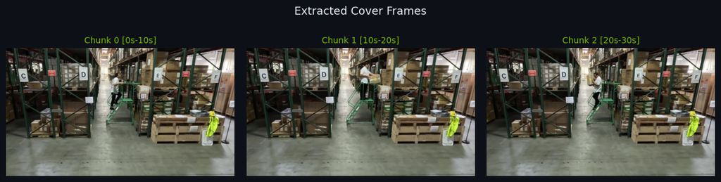

```python
FORCE_LIVE_M1 = False  # ← Set True to clear cache and re-run this mission

if FORCE_LIVE_M1:
    for f in CAPTIONS_DIR.glob(f"*{m1_stem}*"): f.unlink(); print(f"  Cleared: {f.name}")
    for f in (FRAMES_DIR / m1_stem).glob("*"): f.unlink()
    if (FRAMES_DIR / m1_stem).exists(): (FRAMES_DIR / m1_stem).rmdir()
    print("✓ Mission 1 cache cleared — re-running fresh\n")

m1_stem = "warehouse_safety_0002"
m1_frames_dir = FRAMES_DIR / m1_stem
m1_chunks_cache = CAPTIONS_DIR / f"chunks_{m1_stem}.json"
if m1_chunks_cache.exists():
    m1_chunks = json.loads(m1_chunks_cache.read_text())
    print(f"✓ Loaded {len(m1_chunks)} chunks from cache")
elif m1_video.exists():
    start = time.time()
    m1_chunks = extract_frames_from_video(m1_video, m1_frames_dir, chunk_duration=10.0, frames_per_chunk=3)
    m1_chunks = [c for c in m1_chunks if c.get("frame_paths")]
    m1_chunks_cache.write_text(json.dumps(m1_chunks, indent=2))
    print(f"✓ {len(m1_chunks)} chunks, frames extracted in {time.time()-start:.1f}s")
else:
    m1_chunks = []
    print("⚠ Video not found — using pre-computed data only")
m1_covers = get_cover_frame(m1_chunks, m1_frames_dir)
if m1_covers:
    n = len(m1_covers)
    fig, axes = plt.subplots(1, n, figsize=(4*n, 3))
    if n == 1: axes = [axes]
    for ax, (cid, img) in zip(axes, m1_covers.items()):
        ax.imshow(np.array(img))
        c = m1_chunks[cid]
        ax.set_title(f"Chunk {cid} [{c['start_time']:.0f}s-{c['end_time']:.0f}s]", fontsize=10, color=NIM_GREEN)
        ax.axis('off')
    plt.suptitle("Extracted Cover Frames", fontsize=13, color='#e6edf3', y=1.02)
    plt.tight_layout()
    plt.show()
```

### Step 2: VLM Captioning — What Does the AI See?

```python
m1_captions_path = CAPTIONS_DIR / f"nim_captions_{m1_stem}.json"
if m1_captions_path.exists():
    m1_captions = json.loads(m1_captions_path.read_text())
    print(f"✓ Loaded {len(m1_captions)} captions from cache")
    print(f"  Model: {m1_captions[0].get('model', VLM_MODEL)}")
else:
    print(f"Running live VLM captioning ({VLM_MODEL}) ...")
    m1_captions = []
    for c in m1_chunks:
        fps = c.get("frame_paths", [])
        if not fps: continue
        frame = fps[len(fps)//2]
        start_t = time.time()
        caption = caption_frame_nim(frame)
        elapsed = time.time() - start_t
        entry = {"chunk_id": c["chunk_id"], "start_time": c["start_time"],
                 "end_time": c["end_time"], "caption": caption,
                 "model": VLM_MODEL, "frame_path": frame}
        m1_captions.append(entry)
        print(f"  Chunk {c['chunk_id']:02d} ({c['start_time']:.0f}s-{c['end_time']:.0f}s) [{elapsed:.1f}s] {caption[:70]}...")
    m1_captions_path.write_text(json.dumps(m1_captions, indent=2))
    print(f"\n✓ {len(m1_captions)} captions saved")
print(f"\n{'─'*80}")
print(f"VLM CAPTION STRIP — {VIDEOS['warehouse_safety']['title']}")
print(f"{'─'*80}")
for c in m1_captions:
    ts = f"[{c['start_time']:5.0f}s - {c['end_time']:5.0f}s]"
    print(f"\nChunk {c['chunk_id']:02d} {ts}")
    print(f"  {c['caption'][:300]}")
```

```
Running live VLM captioning (nvidia/nemotron-nano-12b-v2-vl) ...
  Chunk 00 (0s-10s) [3.5s] This surveillance frame captures a warehouse scene. The warehouse is f...
  Chunk 01 (10s-20s) [3.6s] This surveillance frame captures a warehouse scene. The warehouse is f...
  Chunk 02 (20s-30s) [3.4s] This surveillance frame captures a warehouse setting. The warehouse is...

✓ 3 captions saved

────────────────────────────────────────────────────────────────────────────────
VLM CAPTION STRIP — Warehouse Safety Monitoring
────────────────────────────────────────────────────────────────────────────────

Chunk 00 [    0s -    10s]
  This surveillance frame captures a warehouse scene. The warehouse is filled with tall green metal shelving units, each labeled with letters from C to F. These shelves are densely packed with cardboard boxes of various sizes, some stacked on wooden pallets. A worker in a white shirt and black pants…

Chunk 01 [   10s -    20s]
  This surveillance frame captures a warehouse scene. The warehouse is filled with tall green metal shelving units, each labeled with letters from C to F. These shelves are densely packed with cardboard boxes of various sizes, some stacked high, others neatly arranged on pallets. The floor is a soli…

Chunk 02 [   20s -    30s]
  This surveillance frame captures a warehouse setting. The warehouse is filled with tall green metal shelving units, each labeled with letters from C to F. These shelves are densely packed with cardboard boxes of various sizes, some stacked on pallets. The floor is concrete, and there's a green met…
```

### Step 3: Interactive Follow-up — Ask About What the AI Saw

The captions are now searchable context. Let's ask a specific safety question grounded in the VLM's observations.

```python
PPE_QUESTION = "Based on the video observations, are all workers wearing proper PPE (hard hat, safety vest)? If anyone is not wearing PPE, describe what they were wearing instead."
context = "\n".join([f"[{c['start_time']:.0f}s-{c['end_time']:.0f}s]: {c['caption']}" for c in m1_captions])
prompt = f"""You are a warehouse safety analyst. Answer the question using ONLY the video observations below.

VIDEO OBSERVATIONS:
{context}

QUESTION: {PPE_QUESTION}

Provide a specific, grounded answer with timestamps. If the observations don't contain enough detail, say so."""
m1_qa_cache = CAPTIONS_DIR / f"qa_ppe_{m1_stem}.json"
if m1_qa_cache.exists():
    answer = json.loads(m1_qa_cache.read_text())["answer"]
    print("✓ Loaded cached answer")
else:
    print(f"Asking: {PPE_QUESTION}\n")
    answer = llm_complete(prompt)
    m1_qa_cache.write_text(json.dumps({"question": PPE_QUESTION, "answer": answer}))
display(HTML(f'''
<div style="background:#0d1117;border:1px solid #3fb950;border-radius:8px;padding:16px 20px;max-width:860px;">
  <div style="color:#3fb950;font-weight:bold;font-size:0.9em;">▶ ANALYST QUESTION</div>
  <div style="color:#e6edf3;font-size:1.0em;margin:8px 0;font-style:italic;">"{PPE_QUESTION}"</div>
  <hr style="border-color:#30363d;margin:12px 0;">
  <div style="color:#76b900;font-weight:bold;font-size:0.9em;">◆ AI RESPONSE (grounded in video observations)</div>
  <div style="color:#e6edf3;font-size:0.95em;margin-top:8px;line-height:1.7;white-space:pre-wrap;">{answer}</div>
</div>'''))
```

```
Asking: Based on the video observations, are all workers wearing proper PPE (hard hat, safety vest)? If anyone is not wearing PPE, describe what they were wearing instead.
```

▶ ANALYST QUESTION

"Based on the video observations, are all workers wearing proper PPE (hard hat, safety vest)? If anyone is not wearing PPE, describe what they were wearing instead."

◆ AI RESPONSE (grounded in video observations)

**Answer:** No, not all workers are wearing proper PPE. - **[0s-10s, 10s-20s, 20s-30s]**: The worker is consistently wearing a white shirt and black pants but **no hard hat or safety vest**. - **Safety vest**: A yellow safety vest is visible hanging on a hook in the [10s-20s] frame, but it is not being worn by the worker. The observations do not show any worker wearing a hard hat or a safety vest. Instead, the worker is wearing only a white shirt and black pants.

## Mission 2: Video Summarization

**Video:** Warehouse Operations (`warehouse_short.mp4`)

**The challenge:** A 10-second clip produces a handful of captions. A 2-hour surveillance archive produces 720 captions. No one reads 720 paragraphs. Recursive summarization compresses them into a single operational report — same pattern, any video length.

▶ **Watch the video, then run the summarization pipeline.**

> **📋 Learning Outcome:** *Explain fundamental concepts of AI scaling including throughput, latency, and cost considerations for GEOINT applications*

```python
m2_video = VIDEOS_DIR / "warehouse_short.mp4"
if m2_video.exists():
    display(HTML(f'''
    <div style="background:#0d1117;padding:12px;border-radius:8px;border:1px solid #58a6ff;max-width:640px;">
      <div style="color:#58a6ff;font-weight:bold;font-size:1.05em;margin-bottom:8px;">▶ Mission 2: Watch First, Then Summarize</div>
      <video width="100%" controls style="border-radius:4px;"><source src="{m2_video}" type="video/mp4"></video>
      <div style="color:#8b949e;font-size:0.85em;margin-top:6px;">Watch carefully — did you see anything fall?</div>
    </div>'''))
```

▶ Mission 2: Watch First, Then Summarize

[video not shown]

Watch carefully — did you see anything fall?

### Step 1: Caption the Video (Frame-Based)

```python
FORCE_LIVE_M2 = False  # ← Set True to clear cache and re-run this mission

if FORCE_LIVE_M2:
    for f in CAPTIONS_DIR.glob(f"*{m2_stem}*"): f.unlink(); print(f"  Cleared: {f.name}")
    for f in (FRAMES_DIR / m2_stem).glob("*"): f.unlink()
    if (FRAMES_DIR / m2_stem).exists(): (FRAMES_DIR / m2_stem).rmdir()
    print("✓ Mission 2 cache cleared — re-running fresh\n")

m2_stem = "warehouse_short"
m2_frames_dir = FRAMES_DIR / m2_stem
m2_captions_path = CAPTIONS_DIR / f"nim_captions_{m2_stem}.json"
if m2_captions_path.exists():
    m2_captions = json.loads(m2_captions_path.read_text())
    print(f"✓ Loaded {len(m2_captions)} captions from cache")
else:
    if m2_video.exists():
        m2_chunks = extract_frames_from_video(m2_video, m2_frames_dir, chunk_duration=3.0, frames_per_chunk=3)
        print(f"Running live VLM captioning ({VLM_MODEL}) ...")
        m2_captions = []
        for c in m2_chunks:
            fps = c.get("frame_paths", [])
            if not fps: continue
            frame = fps[len(fps)//2]
            caption = caption_frame_nim(frame)
            m2_captions.append({"chunk_id": c["chunk_id"], "start_time": c["start_time"],
                                "end_time": c["end_time"], "caption": caption, "model": VLM_MODEL})
            print(f"  Chunk {c['chunk_id']:02d}: {caption[:80]}...")
        m2_captions_path.write_text(json.dumps(m2_captions, indent=2))
    else:
        m2_captions = []
for c in m2_captions:
    print(f"\n[{c['start_time']:.0f}s-{c['end_time']:.0f}s] {c['caption'][:200]}")
```

```
Running live VLM captioning (nvidia/nemotron-nano-12b-v2-vl) ...
  Chunk 00: This image depicts a warehouse aisle lined with tall green metal shelving units....
  Chunk 01: This surveillance frame captures a warehouse worker in a yellow vest and hard ha...
  Chunk 02: This surveillance frame captures a warehouse scene. The warehouse is filled with...
  Chunk 03: This surveillance frame captures a warehouse worker in the midst of his duties. ...

[0s-3s] This image depicts a warehouse aisle lined with tall green metal shelving units. The shelves are densely packed with cardboard boxes, some wrapped in plastic. The aisle is well-lit, with overhead fluo

[3s-6s] This surveillance frame captures a warehouse worker in a yellow vest and hard hat carrying two boxes. The worker is walking down an aisle between tall shelving units labeled C, D, E, and F. The shelve

[6s-9s] This surveillance frame captures a warehouse scene. The warehouse is filled with tall green metal shelving units, each labeled with letters from C to F. These shelves are densely packed with cardboard

[9s-10s] This surveillance frame captures a warehouse worker in the midst of his duties. He is wearing a yellow hard hat and a reflective vest, indicating adherence to safety protocols. The worker is in the pr
```

### Step 2: Recursive Summarization → Operational Report

```python
m2_summary_path = CAPTIONS_DIR / f"nim_summary_{m2_stem}.json"
if m2_summary_path.exists():
    m2_summary = json.loads(m2_summary_path.read_text())
    print(f"✓ Loaded cached summary ({len(m2_summary['final_report'])} chars)")
elif m2_captions:
    print("Running recursive summarization...")
    m2_summary = recursive_summarize(m2_captions)
    m2_summary_path.write_text(json.dumps(m2_summary, indent=2))
    print(f"✓ Summary generated ({len(m2_summary['final_report'])} chars)")
else:
    m2_summary = {"final_report": "No captions available.", "group_summaries": []}
display(HTML(f'''
<div style="background:#0d1117; border:1px solid #58a6ff; border-radius:8px; padding:20px 28px; max-width:860px;">
  <div style="color:#58a6ff; font-size:0.9em; font-weight:bold; margin-bottom:12px;">■ OPERATIONAL REPORT · NVIDIA VSS · {LLM_MODEL.split("/")[-1]}</div>
  <div style="color:#e6edf3; font-size:0.95em; line-height:1.7; white-space:pre-wrap;">{m2_summary["final_report"]}</div>
</div>'''))
```

```
Running recursive summarization...
  Group 1/2 summarized
  Group 2/2 summarized
✓ Summary generated (2026 chars)
```

■ OPERATIONAL REPORT · NVIDIA VSS · nvidia-nemotron-nano-9b-v2

**Operational Report: Warehouse Activity Analysis** --- **Executive Summary** The video captures a well-organized, high-efficiency warehouse operation with clear safety protocols. Workers in yellow vests and hard hats navigate aisles between labeled C-F shelving units, demonstrating adherence to safety standards. The scene emphasizes structured workflows, with minimal disruptions and visible inventory management practices. --- **Key Events (with Timestamps)** - **0s–9s**: A worker in a yellow vest and hard hat efficiently transports boxes and pallets through aisles, highlighting organized movement and adherence to safety gear. A fallen box in the foreground (briefly visible) suggests minor handling activity. - **3s–6s**: Worker continues navigating the space, carrying two boxes, underscoring routine logistics tasks. - **6s–9s**: Worker maintains pace, with a pallet displaying a safety vest, reinforcing facility safety culture. - **9s–10s**: Worker lifts a box from a high shelf, showcasing inventory organization and focused task execution. --- **Safety Observations** - **Positive**: Consistent use of yellow vests, hard hats, and clear shelving labels (C-F) indicate strong safety compliance. - **Minor Concern**: A fallen box in the foreground (0s–9s) may require attention to prevent tripping hazards, though it was not actively causing risk. - **Strengths**: Well-lit environment, clear pathways, and organized inventory reduce accident risks. --- **Recommendations** 1. **Safety Audits**: Regularly inspect high shelves and aisles to address potential hazards like the fallen box. 2. **PPE Enforcement**: Ensure all workers consistently wear reflective vests and hard hats during operations. 3. **Training**: Reinforce proper lifting techniques for high-shelf tasks to prevent strain or accidents. 4. **Maintenance**: Address minor clutter (e.g., fallen boxes) promptly to maintain a hazard-free workspace. --- *Report generated by Video Analytics Assistant*

### 🔍 Teachable Moment: What Did the AI Miss?

If you watched the video carefully, you saw a worker **carrying two boxes and dropping one.** The operational report above may mention "a fallen box" — but read the language carefully. It describes a **static observation** (a box on the ground), not the **event** (someone dropping it).

**Why?** Frame-based captioning extracts a snapshot from the middle of each chunk. With coarse chunking (10-second segments), the VLM might miss the box entirely. With finer chunking (3-second segments), the VLM sees the result — a box on the floor — but still misses the action of dropping because a single frame cannot capture motion.

This is not a model failure. It's a **sensing limitation:**

| Approach | What the AI Sees |
| --- | --- |
| **Coarse chunks (10s)** | Worker with PPE, organized warehouse. No mention of a box drop. |
| **Fine chunks (3s)** | Worker carrying two boxes. "A fallen box." Saw the result, not the action. |
| **Video-native inference** | "He drops a box, which rolls away." Saw the full event. |

The difference between *"there's a box on the floor"* and *"someone dropped a box"* is the difference between a housekeeping note and a safety incident report.

**The fix:** Send the entire video clip to the VLM as video, not as individual frames. This lets the model see temporal relationships — motion, cause and effect, before and after.

> **📋 Learning Outcome:** *Troubleshoot common performance issues in AI deployments*

```python
# ── Video-Native Inference: See the Motion ──────────────────────────
m2_video_cache = CAPTIONS_DIR / f"video_native_{m2_stem}.json"
if m2_video_cache.exists():
    m2_video_caption = json.loads(m2_video_cache.read_text())["caption"]
    print("✓ Loaded cached video-native caption")
else:
    print("Running video-native VLM inference (sending full 10s video)...")
    m2_video_caption = video_native_caption(
        m2_video,
        "Describe all events in this warehouse video in detail. "
        "Note any safety incidents, dropped items, or near-misses."
    )
    m2_video_cache.write_text(json.dumps({"caption": m2_video_caption}))

# Build the frame-based summary from actual captions
frame_summary = m2_captions[0]['caption'][:120] + "..." if m2_captions else "No frame-based caption available."

display(HTML(f'''
<div style="background:#0d1117;border:2px solid #3fb950;border-radius:8px;padding:16px 20px;max-width:860px;">
  <div style="color:#3fb950;font-weight:bold;font-size:0.95em;">◆ VIDEO-NATIVE VLM CAPTION (sees motion, not just snapshots)</div>
  <div style="color:#e6edf3;font-size:0.95em;margin-top:10px;line-height:1.7;white-space:pre-wrap;">{m2_video_caption}</div>
</div>
<div style="background:#161b22;border:1px solid #f78166;border-radius:8px;padding:12px 16px;margin-top:12px;max-width:860px;">
  <div style="color:#f78166;font-weight:bold;font-size:0.85em;">⚡ KEY INSIGHT — Frame vs Video Comparison</div>
  <div style="color:#e6edf3;font-size:0.9em;margin-top:6px;">
    <strong>Frame-based (first caption):</strong><br>
    <em style="color:#8b949e;">"{frame_summary}"</em><br><br>
    <strong>Video-native (full clip):</strong><br>
    <em style="color:#3fb950;">"{m2_video_caption[:200]}"</em><br><br>
    <strong>Frames capture snapshots. Video captures the story.</strong>
    This is why production VSS uses Cosmos Reason 2 with video-native inference.
  </div>
</div>'''))
```

```
✓ Loaded cached video-native caption
```

◆ VIDEO-NATIVE VLM CAPTION (sees motion, not just snapshots)

The video shows a warehouse with tall shelves labeled with letters. A worker in a yellow vest and hard hat is seen carrying boxes. The worker drops a box, which rolls away. The worker continues to carry boxes, and the video ends with the worker walking away.

⚡ KEY INSIGHT — Frame vs Video Comparison

**Frame-based (first caption):**  
*"This image depicts a warehouse aisle lined with tall green metal shelving units. The shelves are densely packed with car..."*  
**Video-native (full clip):**  
*"The video shows a warehouse with tall shelves labeled with letters. A worker in a yellow vest and hard hat is seen carrying boxes. The worker drops a box, which rolls away. The worker continues to car"*  
**Frames capture snapshots. Video captures the story.** This is why production VSS uses Cosmos Reason 2 with video-native inference.

### Audience Challenge: Change the Focus

The same captions can produce completely different reports by changing the summarization prompt. Try editing the `FOCUS` variable below and re-running the cell.

**Suggested focuses:**

- `"Focus exclusively on forklift and vehicle movements"`
- `"Focus on worker safety and PPE compliance"`
- `"Generate a timeline of all human activities"`

```python
FOCUS = "Focus on worker safety and PPE compliance"  # ← CHANGE ME
if m2_captions and NIM_API_KEY:
    context = "\n".join([f"[{c['start_time']:.0f}s-{c['end_time']:.0f}s]: {c['caption']}" for c in m2_captions])
    prompt = f"""Summarize these video observations into a focused report.
FOCUS: {FOCUS}
VIDEO OBSERVATIONS:
{context}
Produce a structured report with: Summary, Key Events (with timestamps), and Recommendations."""
    focused_report = llm_complete(prompt)
    display(HTML(f'''
    <div style="background:#0d1117;border:1px solid #f78166;border-radius:8px;padding:16px 20px;max-width:860px;">
      <div style="color:#f78166;font-weight:bold;font-size:0.9em;">◆ FOCUSED REPORT: {FOCUS}</div>
      <div style="color:#e6edf3;font-size:0.95em;margin-top:10px;line-height:1.7;white-space:pre-wrap;">{focused_report}</div>
    </div>'''))
else:
    print("Requires NIM_API_KEY for live re-summarization.")
```

◆ FOCUSED REPORT: Focus on worker safety and PPE compliance

**Report: Worker Safety and PPE Compliance Analysis** --- **Summary** The video observations show a warehouse environment where workers consistently wear yellow safety vests and hard hats, indicating adherence to basic PPE requirements. Workers navigate aisles between tall shelving units, handling boxes and inventory. While safety protocols appear generally followed, a fallen box in one frame poses a potential hazard. The workspace is organized and well-lit, supporting safe operations. --- **Key Events** 1. **[3s-6s]**: Worker in yellow vest and hard hat carries boxes efficiently through aisles, demonstrating proper PPE use and safe movement. 2. **[6s-9s]**: Worker continues PPE compliance while navigating a fallen box in the aisle. No immediate action is taken to clear the hazard. 3. **[9s-10s]**: Worker lifts a box from a high shelf while wearing PPE, highlighting potential risk if lifting techniques are unsafe. --- **Recommendations** 1. **Address Fallen Box**: Implement a protocol to promptly remove or secure loose items (e.g., the fallen box in [6s-9s]) to prevent tripping hazards. 2. **Reinforce Lifting Safety**: Provide training on safe lifting techniques for high shelves to reduce injury risk during inventory tasks. 3. **PPE Maintenance Check**: Ensure vests/hard hats are regularly inspected for damage and replaced as needed. 4. **Clear Pathway Management**: Establish clear rules for aisle traffic to minimize congestion and hazards during movement. --- *Report generated based on video timestamps and focus on safety/PPE compliance.*

## Mission 3: Interactive Q&A

**Video:** Access Control — Tailgating (`test1.mp4`)

**The challenge:** Security cameras generate thousands of hours of footage. An analyst can't watch it all. With VSS, they type a question in plain English: *"Where do you see someone tailgating?"* and get a timestamped, evidence-backed answer in seconds.

This mission demonstrates the full pipeline **and** reveals the same frame-vs-video lesson from Mission 2 in an even more dramatic way.

▶ **Watch the 31-second video. Did you spot the tailgating? Then let's ask the AI.**

> **📋 Learning Outcome:** *Apply embeddings and vector search to enable rapid retrieval from large geospatial datasets*

```python
m3_video = VIDEOS_DIR / "test1.mp4"
if m3_video.exists():
    display(HTML(f'''
    <div style="background:#0d1117;padding:12px;border-radius:8px;border:1px solid #f78166;max-width:640px;">
      <div style="color:#f78166;font-weight:bold;font-size:1.05em;margin-bottom:8px;">▶ Mission 3: Watch First, Then Interrogate</div>
      <video width="100%" controls style="border-radius:4px;"><source src="{m3_video}" type="video/mp4"></video>
      <div style="color:#8b949e;font-size:0.85em;margin-top:6px;">Did you spot the tailgating? How many people? What happened?</div>
    </div>'''))
```

▶ Mission 3: Watch First, Then Interrogate

[video not shown]

Did you spot the tailgating? How many people? What happened?

### Step 1: Frame-Based Pipeline — Chunk, Caption, Embed, Index

First, we run the standard frame-based pipeline with a security-specific captioning prompt. This tells the VLM exactly what to look for — tailgating, piggybacking, access control violations.

```python
FORCE_LIVE_M3 = False  # ← Set True to clear cache and re-run this mission

if FORCE_LIVE_M3:
    for f in CAPTIONS_DIR.glob(f"*test1*"): f.unlink(); print(f"  Cleared: {f.name}")
    for f in EMBEDDINGS_DIR.glob(f"*test1*"): f.unlink(); print(f"  Cleared: {f.name}")
    for f in (FRAMES_DIR / "test1").glob("*"): f.unlink()
    if (FRAMES_DIR / "test1").exists(): (FRAMES_DIR / "test1").rmdir()
    print("✓ Mission 3 cache cleared — re-running fresh\n")

m3_stem = "test1"
m3_frames_dir = FRAMES_DIR / m3_stem
m3_captions_path = CAPTIONS_DIR / f"nim_captions_{m3_stem}.json"
m3_emb_path = EMBEDDINGS_DIR / f"nim_embeddings_{m3_stem}.npy"
m3_index_path = str(EMBEDDINGS_DIR / f"nim_faiss_{m3_stem}.index")

# Chunk and extract frames
if m3_video.exists() and not (FRAMES_DIR / m3_stem).exists():
    m3_chunks = extract_frames_from_video(m3_video, m3_frames_dir, chunk_duration=10.0, frames_per_chunk=3)
    print(f"✓ {len(m3_chunks)} chunks extracted")
elif m3_video.exists():
    m3_chunks = extract_frames_from_video(m3_video, m3_frames_dir, chunk_duration=10.0, frames_per_chunk=3)
    print(f"✓ {len(m3_chunks)} chunks ready")

# Caption with security-specific prompt
if m3_captions_path.exists():
    m3_captions = json.loads(m3_captions_path.read_text())
    print(f"✓ Loaded {len(m3_captions)} captions from cache")
else:
    SECURITY_PROMPT = ("You are monitoring an access control point. Describe this frame in detail. "
                       "Note how many people are present, whether anyone is following another person "
                       "through a gate or door, and any security concerns like tailgating or piggybacking.")
    print(f"Running VLM captioning with security prompt ({VLM_MODEL}) ...")
    m3_captions = []
    for c in m3_chunks:
        fps = c.get("frame_paths", [])
        if not fps: continue
        frame = fps[len(fps)//2]
        caption = caption_frame_nim(frame, prompt=SECURITY_PROMPT)
        m3_captions.append({"chunk_id": c["chunk_id"], "start_time": c["start_time"],
                            "end_time": c["end_time"], "caption": caption, "model": VLM_MODEL})
        print(f"  Chunk {c['chunk_id']:02d}: {caption[:80]}...")
    m3_captions_path.write_text(json.dumps(m3_captions, indent=2))
    print(f"\n✓ {len(m3_captions)} captions saved")

# Embeddings + FAISS
if m3_emb_path.exists():
    m3_embeddings = np.load(str(m3_emb_path)).astype(np.float32)
    print(f"✓ Loaded embeddings: {m3_embeddings.shape}")
else:
    print("Generating embeddings...")
    texts = [c["caption"] for c in m3_captions]
    vecs = embed_texts(texts)
    m3_embeddings = np.array(vecs, dtype=np.float32)
    norms = np.linalg.norm(m3_embeddings, axis=1, keepdims=True)
    m3_embeddings = m3_embeddings / np.maximum(norms, 1e-9)
    np.save(str(m3_emb_path), m3_embeddings)
    print(f"✓ Embeddings: {m3_embeddings.shape}")

dim = m3_embeddings.shape[1]
m3_index = faiss.IndexFlatIP(dim)
m3_index.add(m3_embeddings)
print(f"✓ FAISS index: {m3_index.ntotal} vectors × {dim}d")
```

```
✓ 4 chunks extracted
Running VLM captioning with security prompt (nvidia/nemotron-nano-12b-v2-vl) ...
  Chunk 00: In this frame, there are three people present. Two of them are walking through t...
  Chunk 01: In this frame, there are no people present. The gate is open, but no one is foll...
  Chunk 02: In this frame, there is one person walking through the gate. The person is walki...
  Chunk 03: In the image, there is a single person standing at an access control point. The ...

✓ 4 captions saved
Generating embeddings...
✓ Embeddings: (4, 1024)
✓ FAISS index: 4 vectors × 1024d
```

### Step 2: Semantic Search — Frame-Based Results

```python
QUERY = "Where do you see someone tailgating through the access point?"
m3_search_cache = CAPTIONS_DIR / f"search_{m3_stem}_{hashlib.md5(QUERY.encode()).hexdigest()[:8]}.json"
if m3_search_cache.exists():
    search_results = json.loads(m3_search_cache.read_text())
    print(f"✓ Loaded cached search results")
elif len(m3_embeddings) > 0:
    qvec = np.array(embed_query(QUERY), dtype=np.float32).reshape(1, -1)
    qvec /= max(np.linalg.norm(qvec), 1e-9)
    scores, indices = m3_index.search(qvec, 3)
    search_results = []
    for rank, (score, idx) in enumerate(zip(scores[0], indices[0])):
        if idx < 0: continue
        c = m3_captions[idx]
        search_results.append({"rank": rank+1, "chunk_id": c["chunk_id"],
            "start_time": c["start_time"], "end_time": c["end_time"],
            "caption": c["caption"], "score": float(score)})
    m3_search_cache.write_text(json.dumps(search_results, indent=2))
else:
    search_results = []
print(f'Search: "{QUERY}"\n')
for res in search_results:
    score_col = SUCCESS if res['score'] > 0.85 else (ACCENT if res['score'] > 0.70 else MUTED)
    ts = f"{int(res['start_time']//60):02d}:{int(res['start_time']%60):02d}–{int(res['end_time']//60):02d}:{int(res['end_time']%60):02d}"
    display(HTML(f'''
    <div style="background:#161b22;border:1px solid #30363d;border-radius:6px;padding:12px 16px;margin:8px 0;max-width:860px;border-left:3px solid {score_col};">
      <div style="color:{score_col};font-weight:bold;font-size:0.9em;">Rank {res['rank']} · [{ts}] · Similarity: {res['score']:.3f}</div>
      <div style="color:#e6edf3;font-size:0.92em;margin-top:6px;line-height:1.6;">{res['caption'][:300]}</div>
    </div>'''))
```

```
Search: "Where do you see someone tailgating through the access point?"
```

Rank 1 · [00:30–00:31] · Similarity: 0.565

In the image, there is a single person standing at an access control point. The individual is wearing a dark-colored jacket and light-colored pants. They are positioned facing the camera, with their body slightly angled to the left. There are no other people visible in the frame, and no one is seen

Rank 2 · [00:10–00:20] · Similarity: 0.454

In this frame, there are no people present. The gate is open, but no one is following another person through it. There are no security concerns like tailgating or piggybacking in this frame.

Rank 3 · [00:20–00:30] · Similarity: 0.433

In this frame, there is one person walking through the gate. The person is walking alone and there is no one following them through the gate. There are no security concerns like tailgating or piggybacking.

### 🔍 Teachable Moment: The Three-Way Comparison

Notice the low similarity scores above. The frame-based captions likely said *"no tailgating concerns"* — even though we told the VLM exactly what to look for. Why?

**Tailgating is a motion event.** It only exists as a temporal sequence: Person A scans their badge, the gate opens, Person B follows through without scanning. A single frame shows people near a gate — which looks perfectly normal.

The VLM was primed to look for tailgating, saw the right people at the right gate, and still confidently concluded no tailgating occurred. Because a snapshot can never capture *"following."*

Let's ask the VLM the same question, but send it the **full video** instead of individual frames.

```python
# ── Video-Native Inference: See the Tailgating ─────────────────────
m3_video_cache = CAPTIONS_DIR / f"video_native_{m3_stem}.json"
if m3_video_cache.exists():
    m3_video_caption = json.loads(m3_video_cache.read_text())["caption"]
    print("✓ Loaded cached video-native caption")
else:
    print("Running video-native VLM inference (sending full 31s video)...")
    m3_video_caption = video_native_caption(
        m3_video,
        "Describe all events in this access control video. Note anyone following "
        "another person through a gate, door, or turnstile without scanning their "
        "own badge or credential. This is called 'tailgating' in physical security."
    )
    m3_video_cache.write_text(json.dumps({"caption": m3_video_caption}))

# Build comparison from actual outputs
frame_summary = m3_captions[0]['caption'][:150] + "..." if m3_captions else "No frame-based caption available."

display(HTML(f'''
<div style="background:#0d1117;border:2px solid #3fb950;border-radius:8px;padding:16px 20px;max-width:860px;">
  <div style="color:#3fb950;font-weight:bold;font-size:0.95em;">◆ VIDEO-NATIVE VLM CAPTION (sees the full sequence)</div>
  <div style="color:#e6edf3;font-size:0.95em;margin-top:10px;line-height:1.7;white-space:pre-wrap;">{m3_video_caption}</div>
</div>
<div style="background:#161b22;border:1px solid #f78166;border-radius:8px;padding:12px 16px;margin-top:12px;max-width:860px;">
  <div style="color:#f78166;font-weight:bold;font-size:0.85em;">⚡ KEY INSIGHT — Frame vs Video Comparison</div>
  <div style="color:#e6edf3;font-size:0.9em;margin-top:6px;">
    <strong>Frame-based (with security prompt):</strong><br>
    <em style="color:#8b949e;">"{frame_summary}"</em><br><br>
    <strong>Video-native (full 31s clip):</strong><br>
    <em style="color:#3fb950;">"{m3_video_caption[:200]}"</em><br><br>
    <strong>If your analyst only sees still frames from a drone feed, they miss the event
    that happened between frames. If they see the video, they see the truth.</strong>
  </div>
</div>'''))
```

```
Running video-native VLM inference (sending full 31s video)...
```

◆ VIDEO-NATIVE VLM CAPTION (sees the full sequence)

The video shows a group of four individuals walking through a gated area. One person is seen opening the gate for the others, who then follow through without scanning their own badges or credentials. This behavior is known as 'tailgating' in physical security.

⚡ KEY INSIGHT — Frame vs Video Comparison

**Frame-based (with security prompt):**  
*"In this frame, there are three people present. Two of them are walking through the gate together, while the third person is walking behind them. There..."*  
**Video-native (full 31s clip):**  
*"The video shows a group of four individuals walking through a gated area. One person is seen opening the gate for the others, who then follow through without scanning their own badges or credentials. "*  
**If your analyst only sees still frames from a drone feed, they miss the event that happened between frames. If they see the video, they see the truth.**

### Step 3: RAG Q&A — Grounded in Video-Native Evidence

Now let's use the video-native caption as context for Q&A. This is how production VSS should work: video-native inference feeds the RAG pipeline, so answers are grounded in what actually happened, not what a snapshot suggested.

```python
RAG_QUESTION = "Describe the tailgating incident in detail. How many people were involved? What security measures were visible?"
m3_rag_cache = CAPTIONS_DIR / f"rag_video_{m3_stem}_{hashlib.md5(RAG_QUESTION.encode()).hexdigest()[:8]}.json"
if m3_rag_cache.exists():
    rag_answer = json.loads(m3_rag_cache.read_text())["answer"]
    print("✓ Loaded cached RAG answer")
else:
    prompt = f"""Answer the analyst's question using ONLY the video observation below.
Cite details. If the evidence is insufficient, say so.

VIDEO OBSERVATION:
{m3_video_caption}

QUESTION: {RAG_QUESTION}"""
    rag_answer = llm_complete(prompt, system="You are a physical security analyst providing grounded video analysis.")
    m3_rag_cache.write_text(json.dumps({"question": RAG_QUESTION, "answer": rag_answer}))
display(HTML(f'''
<div style="background:#0d1117;border:1px solid #f78166;border-radius:8px;padding:16px 20px;max-width:860px;">
  <div style="color:#f78166;font-weight:bold;font-size:0.9em;">▶ ANALYST QUESTION</div>
  <div style="color:#e6edf3;font-size:1.0em;margin:8px 0;font-style:italic;">"{RAG_QUESTION}"</div>
  <hr style="border-color:#30363d;margin:12px 0;">
  <div style="color:#76b900;font-weight:bold;font-size:0.9em;">◆ RAG ANSWER (grounded in video-native observation)</div>
  <div style="color:#e6edf3;font-size:0.95em;margin-top:8px;line-height:1.7;white-space:pre-wrap;">{rag_answer}</div>
</div>'''))
```

▶ ANALYST QUESTION

"Describe the tailgating incident in detail. How many people were involved? What security measures were visible?"

◆ RAG ANSWER (grounded in video-native observation)

**Answer:** The tailgating incident involved **four individuals**. One person opened the gated area's entrance, allowing the other three to follow through without scanning their badges or credentials. The only visible security measure was the **gated area itself**, which required physical access control (e.g., a gate that needed to be opened). No other security measures (e.g., badge scanners, cameras, or personnel) were observed in the video. The lack of badge scanning by the followers indicates a failure to enforce the expected security protocol.

### 🎤 Audience Participation: Ask Your Own Question

Change `AUDIENCE_QUERY` below and run the cell. The AI answers using the video-native caption as evidence — the same context that correctly identified the tailgating.

**Suggested queries to try:**

- `"Was the tailgater carrying anything?"`
- `"How many people passed through the access point total?"`
- `"Describe the security measures visible at the entry point"`
- `"Did anyone attempt to stop the unauthorized entry?"`
- `"What time of day does this appear to be?"`

```python
# ══════════════════════════════════════════════════════════════════
# 🎤 TYPE YOUR QUESTION HERE
# ══════════════════════════════════════════════════════════════════
AUDIENCE_QUERY = "Was the tailgater carrying anything?"  # ← CHANGE ME
# ══════════════════════════════════════════════════════════════════

if NIM_API_KEY:
    # Use video-native caption as context (not frame-based FAISS retrieval)
    prompt = f"""Answer using ONLY this video observation. Cite details.

VIDEO OBSERVATION:
{m3_video_caption}

QUESTION: {AUDIENCE_QUERY}"""
    audience_answer = llm_complete(prompt, system="You are a physical security analyst.")
    display(HTML(f'''
    <div style="background:#0d1117;border:2px solid #76b900;border-radius:8px;padding:16px 20px;max-width:860px;">
      <div style="color:#76b900;font-weight:bold;font-size:1.0em;">🎤 AUDIENCE QUESTION</div>
      <div style="color:#e6edf3;font-size:1.05em;margin:8px 0;font-style:italic;">"{AUDIENCE_QUERY}"</div>
      <hr style="border-color:#30363d;margin:12px 0;">
      <div style="color:#76b900;font-weight:bold;font-size:0.9em;">◆ AI ANSWER (grounded in video-native observation)</div>
      <div style="color:#e6edf3;font-size:0.95em;margin-top:8px;line-height:1.7;white-space:pre-wrap;">{audience_answer}</div>
    </div>'''))
else:
    print("Requires NIM_API_KEY for live audience Q&A.")
```

🎤 AUDIENCE QUESTION

"Was the tailgater carrying anything?"

◆ AI ANSWER (grounded in video-native observation)

The video observation does not mention or provide any details about the tailgater (the individual who opened the gate) carrying anything. The description focuses solely on the act of tailgating—opening the gate and others following without scanning credentials. There is no information about objects, bags, or items being carried by the tailgater.

## Governance & Security

Everything we just ran works in a lab. This section is about what it takes to deploy it for real.

### Government-Ready NIM Containers

| Capability | What It Means |
| --- | --- |
| **CVE Scanning** | Every NIM release scanned for vulnerabilities with a published patch SLA |
| **SBOM** | Full Software Bill of Materials — complete transparency on every dependency |
| **FIPS 140-2/3** | Federal Information Processing Standard validated cryptography — required for DoD/IC |
| **GPU Operator Hardening** | Kubernetes operator with security contexts and pod security admission controls |

### Deployment Options

| Scenario | Where NIM Runs | Code Change |
| --- | --- | --- |
| **This notebook** | `integrate.api.nvidia.com` (NVIDIA cloud) | None — just an API key |
| **On-prem / DGX Spark** | Local NIM container on your GPU | Change `NIM_BASE_URL` |
| **Air-gapped / SCIF** | Self-hosted NIM, disconnected network | Same — identical API |

The entire pipeline in this notebook — every `caption_frame_nim`, `video_native_caption`, `llm_complete`, and `embed_texts` call — runs identically against a local NIM deployment. **No code changes required.**

The demo is the deployment.

### Classification Handling

| Concern | VSS Mechanism |
| --- | --- |
| **Data residency** | NIM containers run on-prem; no data leaves the enclave |
| **Classification** | The vector index inherits the classification of its source video |
| **Query auditing** | Every query → analyst ID + timestamp + returned chunks → audit log |
| **Access control** | Row-level security on Elasticsearch; analysts retrieve only what they're cleared for |
| **Model provenance** | NIM containers are signed; model weights hashed at load time |

> **📋 Learning Outcome:** *Establish fundamental security controls and governance practices for AI systems*

> **📋 Learning Outcome:** *Evaluate AI infrastructure options using vendor-neutral criteria*

## What We Covered

```python
display(HTML('''
<div style="border:1px solid #30363d;border-radius:8px;overflow:hidden;max-width:860px;font-family:sans-serif;">
  <div style="background:#161b22;padding:12px 18px;border-bottom:1px solid #30363d;">
    <span style="color:#76b900;font-weight:bold;font-size:1.1em;">■ Session Summary — NVIDIA VSS Pipeline</span>
  </div>
  <table style="width:100%;border-collapse:collapse;background:#0d1117;">
    <thead>
      <tr style="border-bottom:1px solid #30363d;">
        <th style="text-align:left;padding:10px 14px;color:#8b949e;">Mission</th>
        <th style="text-align:left;padding:10px 14px;color:#8b949e;">What We Ran</th>
        <th style="text-align:left;padding:10px 14px;color:#8b949e;">Key Finding</th>
      </tr>
    </thead>
    <tbody>
      <tr style="border-bottom:1px solid #21262d;background:#0d1117;">
        <td style="padding:10px 14px;color:#3fb950;font-weight:bold;">1 — Captioning</td>
        <td style="padding:10px 14px;color:#e6edf3;">Frame-based VLM captions → PPE Q&A</td>
        <td style="padding:10px 14px;color:#e6edf3;">Zero-shot scene understanding — no training labels needed</td>
      </tr>
      <tr style="border-bottom:1px solid #21262d;background:#161b22;">
        <td style="padding:10px 14px;color:#58a6ff;font-weight:bold;">2 — Summarization</td>
        <td style="padding:10px 14px;color:#e6edf3;">Recursive summaries → operational report</td>
        <td style="padding:10px 14px;color:#f78166;">Frame-based missed the box drop; video-native caught it</td>
      </tr>
      <tr style="border-bottom:1px solid #21262d;background:#0d1117;">
        <td style="padding:10px 14px;color:#f78166;font-weight:bold;">3 — Interactive Q&A</td>
        <td style="padding:10px 14px;color:#e6edf3;">Embeddings → FAISS → search → RAG</td>
        <td style="padding:10px 14px;color:#f78166;">Frame-based said "no tailgating"; video-native identified it</td>
      </tr>
      <tr style="background:#161b22;">
        <td style="padding:10px 14px;color:#f78166;font-weight:bold;" colspan="3">
          ⚡ Key Lesson: Frames capture snapshots. Video captures the story. For mission-critical event detection, video-native VLM inference is essential.
        </td>
      </tr>
    </tbody>
  </table>
  <div style="padding:10px 18px;border-top:1px solid #30363d;background:#161b22;color:#8b949e;font-size:0.85em;">
    <strong style="color:#e6edf3;">In full VSS production:</strong>
    VLM → Cosmos-Reason2-8B (video-native) &nbsp;·&nbsp;
    Embeddings → Cosmos-Embed-1 &nbsp;·&nbsp;
    Vector DB → Elasticsearch &nbsp;·&nbsp;
    Scale → N GPU workers = linear throughput
  </div>
</div>
'''))
```

■ Session Summary — NVIDIA VSS Pipeline

| Mission | What We Ran | Key Finding |
| --- | --- | --- |
| 1 — Captioning | Frame-based VLM captions → PPE Q&A | Zero-shot scene understanding — no training labels needed |
| 2 — Summarization | Recursive summaries → operational report | Frame-based missed the box drop; video-native caught it |
| 3 — Interactive Q&A | Embeddings → FAISS → search → RAG | Frame-based said "no tailgating"; video-native identified it |
| ⚡ Key Lesson: Frames capture snapshots. Video captures the story. For mission-critical event detection, video-native VLM inference is essential. |  |  |

**In full VSS production:** VLM → Cosmos-Reason2-8B (video-native) · Embeddings → Cosmos-Embed-1 · Vector DB → Elasticsearch · Scale → N GPU workers = linear throughput

### Resources

- **VSS Blueprint**: [build.nvidia.com/nvidia/video-search-and-summarization](https://build.nvidia.com/nvidia/video-search-and-summarization/blueprintcard)
- **VSS Documentation**: [docs.nvidia.com/vss/latest](https://docs.nvidia.com/vss/latest/)
- **VSS GitHub**: github.com/NVIDIA-AI-Blueprints/video-search-and-summarization
- **NIM Models**: build.nvidia.com/explore/vision
- **GTC DLI Course**: DLIT81774 — Build a Video Analytics AI Agent With Vision Language Models
- **Sample Video Assets**: NGC `nvidia/vss-warehouse`, `nvidia/vss-developer`, `nvidia/vss-public-safety`

*Scaling AI for GEOINT · GEOINT 2026 Symposium · Kevin Green, Ph.D. & Keith Ober · NVIDIA*